# Risk Factor Analysis

## Outcome Variable

**Outcome Variable:** dead624

## Predictor Variables

**Intervention Variable:** ever_sunderweight06

**Adjustment Set:**

- sex
- arm
- brthmon
- vagbrth
- impfloor
- hhwealth_quart
- W_mage
- W_mhtcm
- W_mwtkg
- W_mbmi
- W_meducyrs
- W_feducyrs
- W_nrooms
- W_parity
- impsan
- safeh20
- delta_vagbrth
- delta_impfloor
- delta_hhwealth_quart
- delta_W_mage
- delta_W_mhtcm
- delta_W_mwtkg
- delta_W_mbmi
- delta_W_meducyrs
- delta_W_feducyrs
- delta_W_nrooms
- delta_W_parity
- delta_impsan
- delta_safeh20

## Stratifying Variables

The analysis was stratified on these variable(s):

- studyid
- country

## Data Summary

| studyid | country | ever_sunderweight06 | dead624 | n_cell | n | outcome_variable |
| --- | --- | --- | --- | --- | --- | --- |
| ki0047075b-MAL-ED | BANGLADESH | 0 | 0 | 224 | 240 | dead624 |
| ki0047075b-MAL-ED | BANGLADESH | 0 | 1 | 0 | 240 | dead624 |
| ki0047075b-MAL-ED | BANGLADESH | 1 | 0 | 16 | 240 | dead624 |
| ki0047075b-MAL-ED | BANGLADESH | 1 | 1 | 0 | 240 | dead624 |
| ki0047075b-MAL-ED | INDIA | 0 | 0 | 204 | 235 | dead624 |
| ki0047075b-MAL-ED | INDIA | 0 | 1 | 0 | 235 | dead624 |
| ki0047075b-MAL-ED | INDIA | 1 | 0 | 31 | 235 | dead624 |
| ki0047075b-MAL-ED | INDIA | 1 | 1 | 0 | 235 | dead624 |
| ki0047075b-MAL-ED | PERU | 0 | 0 | 263 | 273 | dead624 |
| ki0047075b-MAL-ED | PERU | 0 | 1 | 1 | 273 | dead624 |
| ki0047075b-MAL-ED | PERU | 1 | 0 | 9 | 273 | dead624 |
| ki0047075b-MAL-ED | PERU | 1 | 1 | 0 | 273 | dead624 |
| ki0047075b-MAL-ED | SOUTH AFRICA | 0 | 0 | 249 | 261 | dead624 |
| ki0047075b-MAL-ED | SOUTH AFRICA | 0 | 1 | 0 | 261 | dead624 |
| ki0047075b-MAL-ED | SOUTH AFRICA | 1 | 0 | 12 | 261 | dead624 |
| ki0047075b-MAL-ED | SOUTH AFRICA | 1 | 1 | 0 | 261 | dead624 |
| ki0047075b-MAL-ED | TANZANIA, UNITED REPUBLIC OF | 0 | 0 | 237 | 245 | dead624 |
| ki0047075b-MAL-ED | TANZANIA, UNITED REPUBLIC OF | 0 | 1 | 0 | 245 | dead624 |
| ki0047075b-MAL-ED | TANZANIA, UNITED REPUBLIC OF | 1 | 0 | 8 | 245 | dead624 |
| ki0047075b-MAL-ED | TANZANIA, UNITED REPUBLIC OF | 1 | 1 | 0 | 245 | dead624 |
| ki1000109-EE | PAKISTAN | 0 | 0 | 215 | 375 | dead624 |
| ki1000109-EE | PAKISTAN | 0 | 1 | 1 | 375 | dead624 |
| ki1000109-EE | PAKISTAN | 1 | 0 | 156 | 375 | dead624 |
| ki1000109-EE | PAKISTAN | 1 | 1 | 3 | 375 | dead624 |
| ki1000304-VITAMIN-A | INDIA | 0 | 0 | 2673 | 3615 | dead624 |
| ki1000304-VITAMIN-A | INDIA | 0 | 1 | 14 | 3615 | dead624 |
| ki1000304-VITAMIN-A | INDIA | 1 | 0 | 910 | 3615 | dead624 |
| ki1000304-VITAMIN-A | INDIA | 1 | 1 | 18 | 3615 | dead624 |
| ki1000304b-SAS-CompFeed | INDIA | 0 | 0 | 1164 | 1389 | dead624 |
| ki1000304b-SAS-CompFeed | INDIA | 0 | 1 | 5 | 1389 | dead624 |
| ki1000304b-SAS-CompFeed | INDIA | 1 | 0 | 213 | 1389 | dead624 |
| ki1000304b-SAS-CompFeed | INDIA | 1 | 1 | 7 | 1389 | dead624 |
| ki1000304b-SAS-FoodSuppl | INDIA | 0 | 0 | 291 | 400 | dead624 |
| ki1000304b-SAS-FoodSuppl | INDIA | 0 | 1 | 1 | 400 | dead624 |
| ki1000304b-SAS-FoodSuppl | INDIA | 1 | 0 | 105 | 400 | dead624 |
| ki1000304b-SAS-FoodSuppl | INDIA | 1 | 1 | 3 | 400 | dead624 |
| ki1017093b-PROVIDE | BANGLADESH | 0 | 0 | 572 | 617 | dead624 |
| ki1017093b-PROVIDE | BANGLADESH | 0 | 1 | 2 | 617 | dead624 |
| ki1017093b-PROVIDE | BANGLADESH | 1 | 0 | 43 | 617 | dead624 |
| ki1017093b-PROVIDE | BANGLADESH | 1 | 1 | 0 | 617 | dead624 |
| ki1066203-TanzaniaChild2 | TANZANIA, UNITED REPUBLIC OF | 0 | 0 | 2034 | 2096 | dead624 |
| ki1066203-TanzaniaChild2 | TANZANIA, UNITED REPUBLIC OF | 0 | 1 | 0 | 2096 | dead624 |
| ki1066203-TanzaniaChild2 | TANZANIA, UNITED REPUBLIC OF | 1 | 0 | 62 | 2096 | dead624 |
| ki1066203-TanzaniaChild2 | TANZANIA, UNITED REPUBLIC OF | 1 | 1 | 0 | 2096 | dead624 |
| ki1101329-Keneba | GAMBIA | 0 | 0 | 2270 | 2464 | dead624 |
| ki1101329-Keneba | GAMBIA | 0 | 1 | 30 | 2464 | dead624 |
| ki1101329-Keneba | GAMBIA | 1 | 0 | 153 | 2464 | dead624 |
| ki1101329-Keneba | GAMBIA | 1 | 1 | 11 | 2464 | dead624 |
| ki1112895-Burkina Faso Zn | BURKINA FASO | 0 | 0 | 313 | 336 | dead624 |
| ki1112895-Burkina Faso Zn | BURKINA FASO | 0 | 1 | 2 | 336 | dead624 |
| ki1112895-Burkina Faso Zn | BURKINA FASO | 1 | 0 | 21 | 336 | dead624 |
| ki1112895-Burkina Faso Zn | BURKINA FASO | 1 | 1 | 0 | 336 | dead624 |
| ki1113344-GMS-Nepal | NEPAL | 0 | 0 | 508 | 592 | dead624 |
| ki1113344-GMS-Nepal | NEPAL | 0 | 1 | 1 | 592 | dead624 |
| ki1113344-GMS-Nepal | NEPAL | 1 | 0 | 82 | 592 | dead624 |
| ki1113344-GMS-Nepal | NEPAL | 1 | 1 | 1 | 592 | dead624 |
| ki1126311-ZVITAMBO | ZIMBABWE | 0 | 0 | 10798 | 11707 | dead624 |
| ki1126311-ZVITAMBO | ZIMBABWE | 0 | 1 | 296 | 11707 | dead624 |
| ki1126311-ZVITAMBO | ZIMBABWE | 1 | 0 | 503 | 11707 | dead624 |
| ki1126311-ZVITAMBO | ZIMBABWE | 1 | 1 | 110 | 11707 | dead624 |
| ki1148112-iLiNS-DOSE | MALAWI | 0 | 0 | 1593 | 1759 | dead624 |
| ki1148112-iLiNS-DOSE | MALAWI | 0 | 1 | 105 | 1759 | dead624 |
| ki1148112-iLiNS-DOSE | MALAWI | 1 | 0 | 53 | 1759 | dead624 |
| ki1148112-iLiNS-DOSE | MALAWI | 1 | 1 | 8 | 1759 | dead624 |
| ki1148112-iLiNS-DYAD-M | MALAWI | 0 | 0 | 1059 | 1158 | dead624 |
| ki1148112-iLiNS-DYAD-M | MALAWI | 0 | 1 | 19 | 1158 | dead624 |
| ki1148112-iLiNS-DYAD-M | MALAWI | 1 | 0 | 75 | 1158 | dead624 |
| ki1148112-iLiNS-DYAD-M | MALAWI | 1 | 1 | 5 | 1158 | dead624 |
| kiGH5241-JiVitA-3 | BANGLADESH | 0 | 0 | 17600 | 21023 | dead624 |
| kiGH5241-JiVitA-3 | BANGLADESH | 0 | 1 | 169 | 21023 | dead624 |
| kiGH5241-JiVitA-3 | BANGLADESH | 1 | 0 | 3153 | 21023 | dead624 |
| kiGH5241-JiVitA-3 | BANGLADESH | 1 | 1 | 101 | 21023 | dead624 |
| kiGH5241-JiVitA-4 | BANGLADESH | 0 | 0 | 4708 | 5266 | dead624 |
| kiGH5241-JiVitA-4 | BANGLADESH | 0 | 1 | 31 | 5266 | dead624 |
| kiGH5241-JiVitA-4 | BANGLADESH | 1 | 0 | 511 | 5266 | dead624 |
| kiGH5241-JiVitA-4 | BANGLADESH | 1 | 1 | 16 | 5266 | dead624 |

The following strata were considered:

- studyid: ki0047075b-MAL-ED, country: BANGLADESH
- studyid: ki0047075b-MAL-ED, country: INDIA
- studyid: ki0047075b-MAL-ED, country: PERU
- studyid: ki0047075b-MAL-ED, country: SOUTH AFRICA
- studyid: ki0047075b-MAL-ED, country: TANZANIA, UNITED REPUBLIC OF
- studyid: ki1000109-EE, country: PAKISTAN
- studyid: ki1000304-VITAMIN-A, country: INDIA
- studyid: ki1000304b-SAS-CompFeed, country: INDIA
- studyid: ki1000304b-SAS-FoodSuppl, country: INDIA
- studyid: ki1017093b-PROVIDE, country: BANGLADESH
- studyid: ki1066203-TanzaniaChild2, country: TANZANIA, UNITED REPUBLIC OF
- studyid: ki1101329-Keneba, country: GAMBIA
- studyid: ki1112895-Burkina Faso Zn, country: BURKINA FASO
- studyid: ki1113344-GMS-Nepal, country: NEPAL
- studyid: ki1126311-ZVITAMBO, country: ZIMBABWE
- studyid: ki1148112-iLiNS-DOSE, country: MALAWI
- studyid: ki1148112-iLiNS-DYAD-M, country: MALAWI
- studyid: kiGH5241-JiVitA-3, country: BANGLADESH
- studyid: kiGH5241-JiVitA-4, country: BANGLADESH

### Dropped Strata

Some strata were dropped due to rare outcomes:

- studyid: ki0047075b-MAL-ED, country: BANGLADESH
- studyid: ki0047075b-MAL-ED, country: INDIA
- studyid: ki0047075b-MAL-ED, country: PERU
- studyid: ki0047075b-MAL-ED, country: SOUTH AFRICA
- studyid: ki0047075b-MAL-ED, country: TANZANIA, UNITED REPUBLIC OF
- studyid: ki1000109-EE, country: PAKISTAN
- studyid: ki1000304b-SAS-FoodSuppl, country: INDIA
- studyid: ki1017093b-PROVIDE, country: BANGLADESH
- studyid: ki1066203-TanzaniaChild2, country: TANZANIA, UNITED REPUBLIC OF
- studyid: ki1112895-Burkina Faso Zn, country: BURKINA FASO
- studyid: ki1113344-GMS-Nepal, country: NEPAL

## Methods Detail

We’re interested in the causal parameters $E[Y_a]$ for all values of $a \in \mathcal{A}$. These parameters represent the mean outcome if, possibly contrary to fact, we intervened to set all units to have $A=a$. Under the randomization and positivity assumptions, these are identified by the statistical parameters $\psi_a=E_W[E_{Y|A,W}(Y|A=a,W)]$. In addition, we’re interested in the mean of $Y$, $E[Y]$ under no intervention (the observed mean). We will estimate these parameters by using SuperLearner to fit the relevant likelihood factors – $E_{Y|A,W}(Y|A=a,W)$ and $p(A=a|W)$, and then updating our likelihood fit using a joint TMLE.

For unadjusted analyses ($W=\{\}$), initial likelihoods were estimated using Lrnr_glm to estimate the simple $E(Y|A)$ and Lrnr_mean to estimate $p(A)$. For adjusted analyses, a small library containing Lrnr_glmnet, Lrnr_xgboost, and Lrnr_mean was used.

Having estimated these parameters, we will then use the delta method to estimate relative risks and attributable risks relative to a prespecified baseline level of $A$.

# Results Detail

## Results Plots

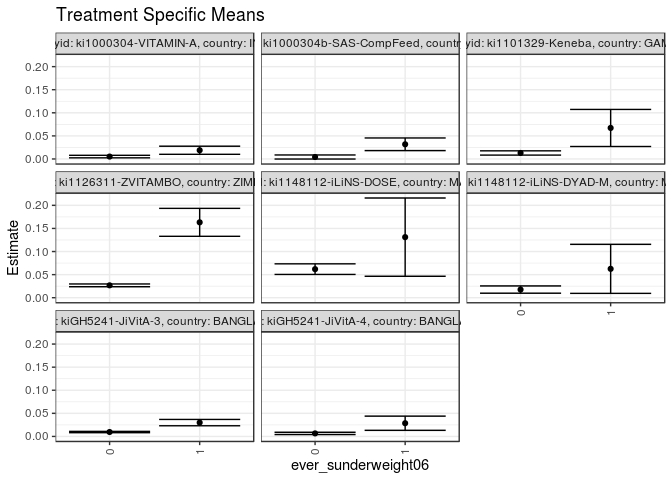

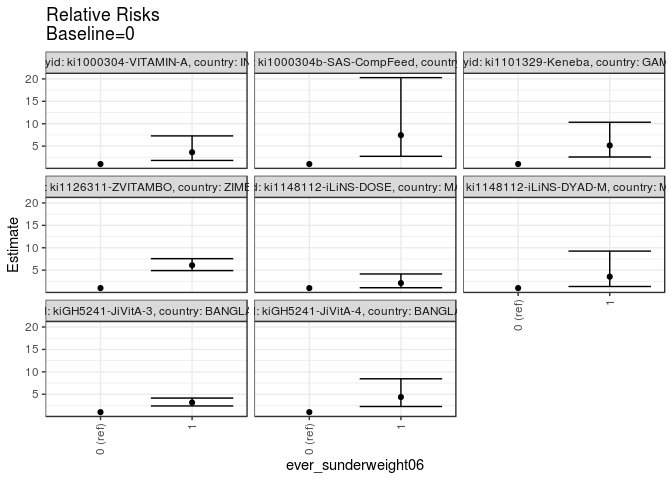

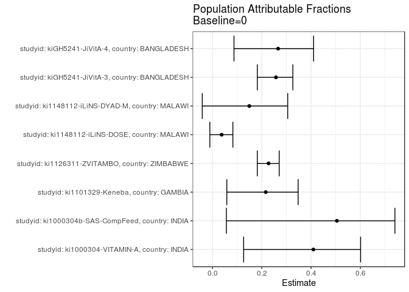

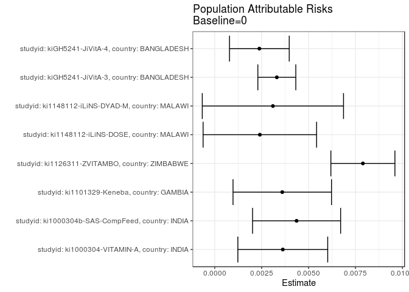

## Results Table

### Parameter: TSM

| studyid | country | intervention_level | baseline_level | estimate | ci_lower | ci_upper |
| --- | --- | --- | --- | --- | --- | --- |
| ki1000304-VITAMIN-A | INDIA | 0 | NA | 0.0052255 | 0.0024934 | 0.0079576 |
| ki1000304-VITAMIN-A | INDIA | 1 | NA | 0.0189303 | 0.0101826 | 0.0276781 |
| ki1000304b-SAS-CompFeed | INDIA | 0 | NA | 0.0042772 | -0.0001115 | 0.0086658 |
| ki1000304b-SAS-CompFeed | INDIA | 1 | NA | 0.0318182 | 0.0181644 | 0.0454719 |
| ki1101329-Keneba | GAMBIA | 0 | NA | 0.0130407 | 0.0084011 | 0.0176804 |
| ki1101329-Keneba | GAMBIA | 1 | NA | 0.0672015 | 0.0270636 | 0.1073394 |
| ki1126311-ZVITAMBO | ZIMBABWE | 0 | NA | 0.0267842 | 0.0237830 | 0.0297855 |
| ki1126311-ZVITAMBO | ZIMBABWE | 1 | NA | 0.1632167 | 0.1329448 | 0.1934887 |
| ki1148112-iLiNS-DOSE | MALAWI | 0 | NA | 0.0618375 | 0.0503779 | 0.0732970 |
| ki1148112-iLiNS-DOSE | MALAWI | 1 | NA | 0.1311475 | 0.0464131 | 0.2158819 |
| ki1148112-iLiNS-DYAD-M | MALAWI | 0 | NA | 0.0176252 | 0.0097669 | 0.0254836 |
| ki1148112-iLiNS-DYAD-M | MALAWI | 1 | NA | 0.0625000 | 0.0094340 | 0.1155660 |
| kiGH5241-JiVitA-3 | BANGLADESH | 0 | NA | 0.0095339 | 0.0080671 | 0.0110007 |
| kiGH5241-JiVitA-3 | BANGLADESH | 1 | NA | 0.0299510 | 0.0231235 | 0.0367785 |
| kiGH5241-JiVitA-4 | BANGLADESH | 0 | NA | 0.0065466 | 0.0040857 | 0.0090076 |
| kiGH5241-JiVitA-4 | BANGLADESH | 1 | NA | 0.0285832 | 0.0132152 | 0.0439512 |

### Parameter: E(Y)

| studyid | country | intervention_level | baseline_level | estimate | ci_lower | ci_upper |
| --- | --- | --- | --- | --- | --- | --- |
| ki1000304-VITAMIN-A | INDIA | NA | NA | 0.0088520 | 0.0057982 | 0.0119058 |
| ki1000304b-SAS-CompFeed | INDIA | NA | NA | 0.0086393 | 0.0042356 | 0.0130430 |
| ki1101329-Keneba | GAMBIA | NA | NA | 0.0166396 | 0.0115878 | 0.0216914 |
| ki1126311-ZVITAMBO | ZIMBABWE | NA | NA | 0.0346801 | 0.0313656 | 0.0379946 |
| ki1148112-iLiNS-DOSE | MALAWI | NA | NA | 0.0642410 | 0.0527799 | 0.0757022 |
| ki1148112-iLiNS-DYAD-M | MALAWI | NA | NA | 0.0207254 | 0.0125165 | 0.0289343 |
| kiGH5241-JiVitA-3 | BANGLADESH | NA | NA | 0.0128431 | 0.0112928 | 0.0143934 |
| kiGH5241-JiVitA-4 | BANGLADESH | NA | NA | 0.0089252 | 0.0062212 | 0.0116291 |

### Parameter: RR

| studyid | country | intervention_level | baseline_level | estimate | ci_lower | ci_upper |
| --- | --- | --- | --- | --- | --- | --- |
| ki1000304-VITAMIN-A | INDIA | 0 | 0 | 1.000000 | 1.000000 | 1.000000 |
| ki1000304-VITAMIN-A | INDIA | 1 | 0 | 3.622661 | 1.803035 | 7.278657 |
| ki1000304b-SAS-CompFeed | INDIA | 0 | 0 | 1.000000 | 1.000000 | 1.000000 |
| ki1000304b-SAS-CompFeed | INDIA | 1 | 0 | 7.439091 | 2.727800 | 20.287438 |
| ki1101329-Keneba | GAMBIA | 0 | 0 | 1.000000 | 1.000000 | 1.000000 |
| ki1101329-Keneba | GAMBIA | 1 | 0 | 5.153200 | 2.570700 | 10.330054 |
| ki1126311-ZVITAMBO | ZIMBABWE | 0 | 0 | 1.000000 | 1.000000 | 1.000000 |
| ki1126311-ZVITAMBO | ZIMBABWE | 1 | 0 | 6.093760 | 4.906996 | 7.567545 |
| ki1148112-iLiNS-DOSE | MALAWI | 0 | 0 | 1.000000 | 1.000000 | 1.000000 |
| ki1148112-iLiNS-DOSE | MALAWI | 1 | 0 | 2.120843 | 1.082921 | 4.153557 |
| ki1148112-iLiNS-DYAD-M | MALAWI | 0 | 0 | 1.000000 | 1.000000 | 1.000000 |
| ki1148112-iLiNS-DYAD-M | MALAWI | 1 | 0 | 3.546053 | 1.359113 | 9.251981 |
| kiGH5241-JiVitA-3 | BANGLADESH | 0 | 0 | 1.000000 | 1.000000 | 1.000000 |
| kiGH5241-JiVitA-3 | BANGLADESH | 1 | 0 | 3.141520 | 2.382852 | 4.141740 |
| kiGH5241-JiVitA-4 | BANGLADESH | 0 | 0 | 1.000000 | 1.000000 | 1.000000 |
| kiGH5241-JiVitA-4 | BANGLADESH | 1 | 0 | 4.366084 | 2.258514 | 8.440365 |

### Parameter: PAR

| studyid | country | intervention_level | baseline_level | estimate | ci_lower | ci_upper |
| --- | --- | --- | --- | --- | --- | --- |
| ki1000304-VITAMIN-A | INDIA | 0 | NA | 0.0036265 | 0.0012318 | 0.0060211 |
| ki1000304b-SAS-CompFeed | INDIA | 0 | NA | 0.0043621 | 0.0020152 | 0.0067091 |
| ki1101329-Keneba | GAMBIA | 0 | NA | 0.0035989 | 0.0009743 | 0.0062234 |
| ki1126311-ZVITAMBO | ZIMBABWE | 0 | NA | 0.0078959 | 0.0061890 | 0.0096027 |
| ki1148112-iLiNS-DOSE | MALAWI | 0 | NA | 0.0024036 | -0.0006203 | 0.0054275 |
| ki1148112-iLiNS-DYAD-M | MALAWI | 0 | NA | 0.0031002 | -0.0006634 | 0.0068637 |
| kiGH5241-JiVitA-3 | BANGLADESH | 0 | NA | 0.0033092 | 0.0022981 | 0.0043202 |
| kiGH5241-JiVitA-4 | BANGLADESH | 0 | NA | 0.0023785 | 0.0007865 | 0.0039706 |

### Parameter: PAF

| studyid | country | intervention_level | baseline_level | estimate | ci_lower | ci_upper |
| --- | --- | --- | --- | --- | --- | --- |
| ki1000304-VITAMIN-A | INDIA | 0 | NA | 0.4096777 | 0.1266972 | 0.6009626 |
| ki1000304b-SAS-CompFeed | INDIA | 0 | NA | 0.5049187 | 0.0566503 | 0.7401754 |
| ki1101329-Keneba | GAMBIA | 0 | NA | 0.2162839 | 0.0584007 | 0.3476939 |
| ki1126311-ZVITAMBO | ZIMBABWE | 0 | NA | 0.2276771 | 0.1819956 | 0.2708076 |
| ki1148112-iLiNS-DOSE | MALAWI | 0 | NA | 0.0374152 | -0.0103929 | 0.0829612 |
| ki1148112-iLiNS-DYAD-M | MALAWI | 0 | NA | 0.1495826 | -0.0410752 | 0.3053241 |
| kiGH5241-JiVitA-3 | BANGLADESH | 0 | NA | 0.2576606 | 0.1821293 | 0.3262166 |
| kiGH5241-JiVitA-4 | BANGLADESH | 0 | NA | 0.2664971 | 0.0874772 | 0.4103966 |